# Individual differences

In **Pilot 1**, there are 40 subjects who did the curiosity personal trait questionaire. The following analysis will only include these subjects who had personal trait scores.

# 1 Relationship between trait score and slope of curiosity-memory relationship

## 1.1 Outside

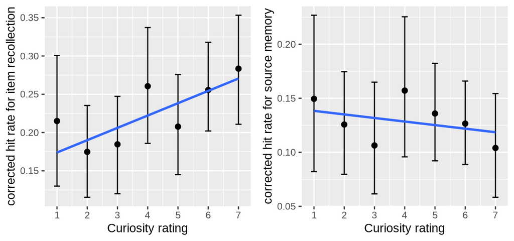

### 1.1.1 Item recollection

#### 1.1.1.1 Correlation with the average score

```
##                  Model df       AIC        BIC   logLik   Test  L.Ratio p-value
## baseline.rating      1  3 -112.4064 -102.01487 59.20318
## rating.intercept     2  4 -115.8169 -101.96155 61.90844 1 vs 2 5.410516  0.0200
## rating.slope         3  6 -117.0497  -96.26669 64.52484 2 vs 3 5.232807  0.0731
## tr.intercept         4  7 -115.2734  -91.02656 64.63669 3 vs 4 0.223698  0.6362
## tr.slope             5  8 -113.4929  -85.78221 64.74643 4 vs 5 0.219479  0.6394
```

#### 1.1.1.2 Correlation with the PC score

```
##                  Model df       AIC        BIC   logLik   Test  L.Ratio p-value
## baseline.rating      1  3 -112.4064 -102.01487 59.20318
## rating.intercept     2  4 -115.8169 -101.96155 61.90844 1 vs 2 5.410516  0.0200
## rating.slope         3  6 -117.0497  -96.26669 64.52484 2 vs 3 5.232807  0.0731
## PC.intercept         4  7 -115.4498  -91.20297 64.72490 3 vs 4 0.400107  0.5270
## PC.slope             5  8 -113.4906  -85.77991 64.74528 4 vs 5 0.040770  0.8400
```

#### 1.1.1.3 Correlation with the EC score

```
##                  Model df       AIC        BIC   logLik   Test  L.Ratio p-value
## baseline.rating      1  3 -112.4064 -102.01487 59.20318
## rating.intercept     2  4 -115.8169 -101.96155 61.90844 1 vs 2 5.410516  0.0200
## rating.slope         3  6 -117.0497  -96.26669 64.52484 2 vs 3 5.232807  0.0731
## EC.intercept         4  7 -115.1003  -90.85343 64.55013 3 vs 4 0.050573  0.8221
## EC.slope             5  8 -114.1968  -86.48620 65.09843 4 vs 5 1.096594  0.2950
```

### 1.1.2 Source memory

#### 1.1.2.1 Correlation with the average score

```
##                  Model df       AIC       BIC   logLik   Test   L.Ratio p-value
## baseline.rating      1  3 -223.6668 -213.2753 114.8334
## rating.intercept     2  4 -222.0794 -208.2241 115.0397 1 vs 2 0.4126185  0.5206
## rating.slope         3  6 -218.0728 -197.2898 115.0364 2 vs 3 0.0066289  0.9967
## tr.intercept         4  7 -217.2203 -192.9735 115.6101 3 vs 4 1.1474937  0.2841
## tr.slope             5  8 -215.5642 -187.8536 115.7821 4 vs 5 0.3439777  0.5575
```

#### 1.1.2.2 Correlation with the PC score

```
##                  Model df       AIC       BIC   logLik   Test   L.Ratio p-value
## baseline.rating      1  3 -223.6668 -213.2753 114.8334
## rating.intercept     2  4 -222.0794 -208.2241 115.0397 1 vs 2 0.4126185  0.5206
## rating.slope         3  6 -218.0728 -197.2898 115.0364 2 vs 3 0.0066289  0.9967
## PC.intercept         4  7 -216.9462 -192.6994 115.4731 3 vs 4 0.8734029  0.3500
## PC.slope             5  8 -215.4587 -187.7480 115.7293 4 vs 5 0.5125171  0.4741
```

#### 1.1.2.3 Correlation with the EC score

```
##                  Model df       AIC       BIC   logLik   Test   L.Ratio p-value
## baseline.rating      1  3 -223.6668 -213.2753 114.8334
## rating.intercept     2  4 -222.0794 -208.2241 115.0397 1 vs 2 0.4126185  0.5206
## rating.slope         3  6 -218.0728 -197.2898 115.0364 2 vs 3 0.0066289  0.9967
## EC.intercept         4  7 -217.0585 -192.8117 115.5293 3 vs 4 0.9857200  0.3208
## EC.slope             5  8 -215.1623 -187.4516 115.5811 4 vs 5 0.1037769  0.7473
```

## 1.2 Inside

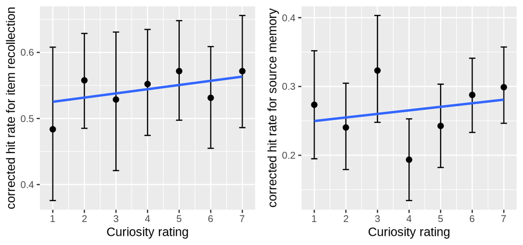

### 1.2.1 Item recollection

#### 1.2.1.1 Correlation with the average score

```
##                  Model df       AIC       BIC   logLik   Test  L.Ratio p-value
## baseline.rating      1  3 -19.93932 -9.547823 12.96966
## rating.intercept     2  4 -18.85389 -4.998564 13.42695 1 vs 2 0.914573  0.3389
## rating.slope         3  6 -16.18872  4.594268 14.09436 2 vs 3 1.334831  0.5130
## tr.intercept         4  7 -14.19586 10.050959 14.09793 3 vs 4 0.007141  0.9327
## tr.slope             5  8 -18.81226  8.898398 17.40613 4 vs 5 6.616393  0.0101
```

```
##                    Value  Std.Error  DF    t-value     p-value
## (Intercept)   0.11636682 0.23439819 194  0.4964493 0.620139473
## CurRating     0.12365310 0.04607587 194  2.6836846 0.007910846
## GN            0.13863697 0.08019105  38  1.7288334 0.091956993
## CurRating:GN -0.04018931 0.01568104 194 -2.5629248 0.011137480
```

#### 1.2.1.2 Correlation with the PC score

```
##                  Model df       AIC       BIC   logLik   Test  L.Ratio p-value
## baseline.rating      1  3 -19.93932 -9.547823 12.96966
## rating.intercept     2  4 -18.85389 -4.998564 13.42695 1 vs 2 0.914573  0.3389
## rating.slope         3  6 -16.18872  4.594268 14.09436 2 vs 3 1.334831  0.5130
## PC.intercept         4  7 -14.25993  9.986889 14.12997 3 vs 4 0.071210  0.7896
## PC.slope             5  8 -19.16104  8.549611 17.58052 4 vs 5 6.901110  0.0086
```

```
##                    Value  Std.Error  DF   t-value     p-value
## (Intercept)   0.08501296 0.21886922 194  0.388419 0.698131909
## CurRating     0.11666989 0.04234850 194  2.754995 0.006428160
## PC            0.14827615 0.07395060  38  2.005070 0.052116897
## CurRating:PC -0.03747782 0.01425043 194 -2.629943 0.009225122
```

#### 1.2.1.3 Correlation with the EC score

```
##                  Model df       AIC       BIC   logLik   Test  L.Ratio p-value
## baseline.rating      1  3 -19.93932 -9.547823 12.96966
## rating.intercept     2  4 -18.85389 -4.998564 13.42695 1 vs 2 0.914573  0.3389
## rating.slope         3  6 -16.18872  4.594268 14.09436 2 vs 3 1.334831  0.5130
## EC.intercept         4  7 -14.33625  9.910569 14.16813 3 vs 4 0.147530  0.7009
## EC.slope             5  8 -16.40008 11.310572 16.20004 4 vs 5 4.063829  0.0438
```

```
##                    Value  Std.Error  DF   t-value    p-value
## (Intercept)   0.28308869 0.20851305 194  1.357655 0.17615043
## CurRating     0.08824786 0.04131557 194  2.135947 0.03393721
## EC            0.08144457 0.07180406  38  1.134261 0.26378974
## CurRating:EC -0.02822877 0.01414033 194 -1.996331 0.04729633
```

### 1.2.2 Source memory

#### 1.2.2.1 Correlation with the average score

```
##                  Model df       AIC        BIC   logLik   Test   L.Ratio
## baseline.rating      1  3 -117.7058 -107.31426 61.85288
## rating.intercept     2  4 -116.9480 -103.09265 62.47399 1 vs 2 1.2422183
## rating.slope         3  6 -114.9746  -94.19161 63.48730 2 vs 3 2.0266226
## tr.intercept         4  7 -113.0822  -88.83541 63.54112 3 vs 4 0.1076383
## tr.slope             5  8 -111.9254  -84.21476 63.96271 4 vs 5 0.8431789
##                  p-value
## baseline.rating
## rating.intercept  0.2650
## rating.slope      0.3630
## tr.intercept      0.7428
## tr.slope          0.3585
```

#### 1.2.2.2 Correlation with the PC score

```
##                  Model df       AIC        BIC   logLik   Test   L.Ratio
## baseline.rating      1  3 -117.7058 -107.31426 61.85288
## rating.intercept     2  4 -116.9480 -103.09265 62.47399 1 vs 2 1.2422183
## rating.slope         3  6 -114.9746  -94.19161 63.48730 2 vs 3 2.0266226
## PC.intercept         4  7 -113.1317  -88.88487 63.56584 3 vs 4 0.1570906
## PC.slope             5  8 -111.1519  -83.44126 63.57596 4 vs 5 0.0202281
##                  p-value
## baseline.rating
## rating.intercept  0.2650
## rating.slope      0.3630
## PC.intercept      0.6918
## PC.slope          0.8869
```

```
##                   Value   Std.Error  DF   t-value    p-value
## (Intercept) 0.191047279 0.101866501 195 1.8754672 0.06222306
## CurRating   0.008193542 0.007337398 195 1.1166823 0.26550425
## PC          0.012835895 0.032507755  38 0.3948564 0.69515655
```

#### 1.2.2.3 Correlation with the EC score

```
##                  Model df       AIC        BIC   logLik   Test   L.Ratio
## baseline.rating      1  3 -117.7058 -107.31426 61.85288
## rating.intercept     2  4 -116.9480 -103.09265 62.47399 1 vs 2 1.2422183
## rating.slope         3  6 -114.9746  -94.19161 63.48730 2 vs 3 2.0266226
## EC.intercept         4  7 -113.9533  -89.70649 63.97666 3 vs 4 0.9787132
## EC.slope             5  8 -114.2440  -86.53336 65.12201 4 vs 5 2.2907073
##                  p-value
## baseline.rating
## rating.intercept  0.2650
## rating.slope      0.3630
## EC.intercept      0.3225
## EC.slope          0.1302
```

# 2 Relationship between trait score and difference between high and low curiosity groups (median-split)

## 2.1 Outside

### 2.1.1 Visualise the relationships

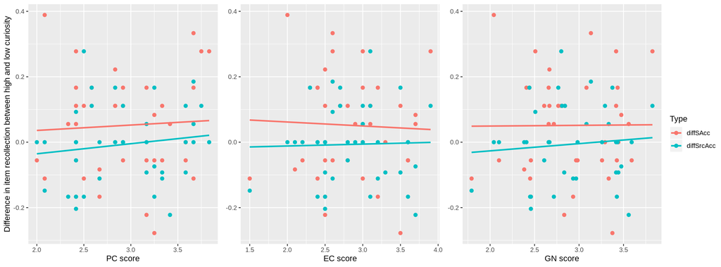

### 2.1.2 Calculate the correlations

#### 2.1.2.1 Item recollection

```
##
##  Pearson's product-moment correlation
##
## data:  outside.hit.rate.curiosity.group.median.diff$diffSAcc and outside.hit.rate.curiosity.group.median.diff$PC
## t = 0.33586, df = 37, p-value = 0.7389
## alternative hypothesis: true correlation is not equal to 0
## 95 percent confidence interval:
##  -0.2649950  0.3643115
## sample estimates:
##        cor
## 0.05513163
```

```
##
##  Pearson's product-moment correlation
##
## data:  outside.hit.rate.curiosity.group.median.diff$diffSAcc and outside.hit.rate.curiosity.group.median.diff$EC
## t = -0.25438, df = 37, p-value = 0.8006
## alternative hypothesis: true correlation is not equal to 0
## 95 percent confidence interval:
##  -0.3526508  0.2773911
## sample estimates:
##         cor
## -0.04178284
```

```
##
##  Pearson's product-moment correlation
##
## data:  outside.hit.rate.curiosity.group.median.diff$diffSAcc and outside.hit.rate.curiosity.group.median.diff$GN
## t = 0.040162, df = 37, p-value = 0.9682
## alternative hypothesis: true correlation is not equal to 0
## 95 percent confidence interval:
##  -0.3095595  0.3214499
## sample estimates:
##         cor
## 0.006602444
```

#### 2.1.2.2 Source memory

```
##
##  Pearson's product-moment correlation
##
## data:  outside.hit.rate.curiosity.group.median.diff$diffSrcAcc and outside.hit.rate.curiosity.group.median.diff$PC
## t = 0.83311, df = 37, p-value = 0.4101
## alternative hypothesis: true correlation is not equal to 0
## 95 percent confidence interval:
##  -0.1878643  0.4326879
## sample estimates:
##       cor
## 0.1356961
```

```
##
##  Pearson's product-moment correlation
##
## data:  outside.hit.rate.curiosity.group.median.diff$diffSrcAcc and outside.hit.rate.curiosity.group.median.diff$EC
## t = 0.15936, df = 37, p-value = 0.8743
## alternative hypothesis: true correlation is not equal to 0
## 95 percent confidence interval:
##  -0.2917386  0.3389058
## sample estimates:
##        cor
## 0.02618915
```

```
##
##  Pearson's product-moment correlation
##
## data:  outside.hit.rate.curiosity.group.median.diff$diffSrcAcc and outside.hit.rate.curiosity.group.median.diff$GN
## t = 0.54311, df = 37, p-value = 0.5903
## alternative hypothesis: true correlation is not equal to 0
## 95 percent confidence interval:
##  -0.2331250  0.3934115
## sample estimates:
##        cor
## 0.08893359
```

## 2.2 Inside

### 2.2.1 Visualise the relationships

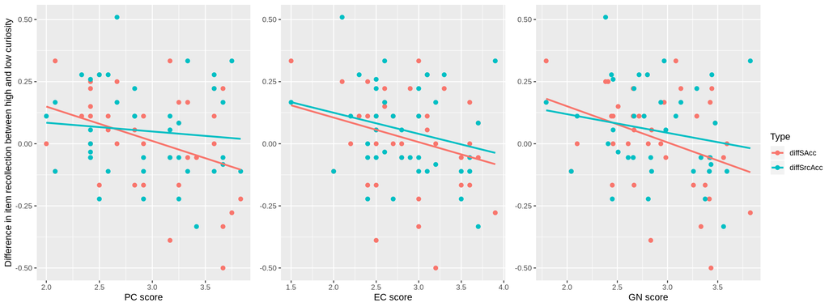

### 2.2.2 Calculate the correlations

#### 2.2.2.1 Item recollection

```
##
##  Pearson's product-moment correlation
##
## data:  inside.hit.rate.curiosity.group.median.diff$diffSAcc and inside.hit.rate.curiosity.group.median.diff$PC
## t = -2.3954, df = 37, p-value = 0.02178
## alternative hypothesis: true correlation is not equal to 0
## 95 percent confidence interval:
##  -0.61125981 -0.05754524
## sample estimates:
##        cor
## -0.3664096
```

```
##
##  Pearson's product-moment correlation
##
## data:  inside.hit.rate.curiosity.group.median.diff$diffSAcc and inside.hit.rate.curiosity.group.median.diff$EC
## t = -1.6995, df = 37, p-value = 0.09762
## alternative hypothesis: true correlation is not equal to 0
## 95 percent confidence interval:
##  -0.53885612  0.05073546
## sample estimates:
##        cor
## -0.2690891
```

```
##
##  Pearson's product-moment correlation
##
## data:  inside.hit.rate.curiosity.group.median.diff$diffSAcc and inside.hit.rate.curiosity.group.median.diff$GN
## t = -2.2867, df = 37, p-value = 0.02803
## alternative hypothesis: true correlation is not equal to 0
## 95 percent confidence interval:
##  -0.60070765 -0.04090945
## sample estimates:
##        cor
## -0.3518845
```

#### 2.2.2.2 Source memory

```
##
##  Pearson's product-moment correlation
##
## data:  inside.hit.rate.curiosity.group.median.diff$diffSrcAcc and inside.hit.rate.curiosity.group.median.diff$PC
## t = -0.59976, df = 37, p-value = 0.5523
## alternative hypothesis: true correlation is not equal to 0
## 95 percent confidence interval:
##  -0.4012196  0.2243383
## sample estimates:
##         cor
## -0.09812423
```

```
##
##  Pearson's product-moment correlation
##
## data:  inside.hit.rate.curiosity.group.median.diff$diffSrcAcc and inside.hit.rate.curiosity.group.median.diff$EC
## t = -1.5238, df = 37, p-value = 0.1361
## alternative hypothesis: true correlation is not equal to 0
## 95 percent confidence interval:
##  -0.51874501  0.07853807
## sample estimates:
##        cor
## -0.2430006
```

```
##
##  Pearson's product-moment correlation
##
## data:  inside.hit.rate.curiosity.group.median.diff$diffSrcAcc and inside.hit.rate.curiosity.group.median.diff$GN
## t = -1.1805, df = 37, p-value = 0.2453
## alternative hypothesis: true correlation is not equal to 0
## 95 percent confidence interval:
##  -0.4773467  0.1329866
## sample estimates:
##        cor
## -0.1905248
```

# 3 Relationship between trait score and curiosity ratings

## 3.1 Across all the rooms

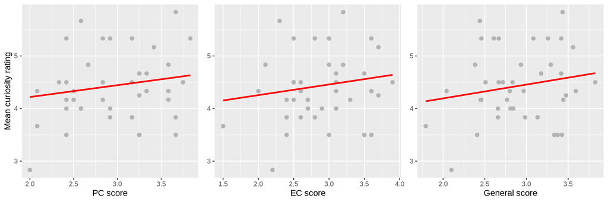

```r
cor.test(trait.ratings$meanCurRating, trait.ratings$PC, method = "pearson")
```

```
##
##  Pearson's product-moment correlation
##
## data:  trait.ratings$meanCurRating and trait.ratings$PC
## t = 1.0747, df = 38, p-value = 0.2893
## alternative hypothesis: true correlation is not equal to 0
## 95 percent confidence interval:
##  -0.1476563  0.4587197
## sample estimates:
##       cor
## 0.1717531
```

```r
cor.test(trait.ratings$meanCurRating, trait.ratings$EC, method = "pearson")
```

```
##
##  Pearson's product-moment correlation
##
## data:  trait.ratings$meanCurRating and trait.ratings$EC
## t = 0.99305, df = 38, p-value = 0.327
## alternative hypothesis: true correlation is not equal to 0
## 95 percent confidence interval:
##  -0.1604138  0.4483401
## sample estimates:
##      cor
## 0.159043
```

```r
cor.test(trait.ratings$meanCurRating, trait.ratings$GN, method = "pearson")
```

```
##
##  Pearson's product-moment correlation
##
## data:  trait.ratings$meanCurRating and trait.ratings$GN
## t = 1.1498, df = 38, p-value = 0.2574
## alternative hypothesis: true correlation is not equal to 0
## 95 percent confidence interval:
##  -0.1359148  0.4681286
## sample estimates:
##       cor
## 0.1833577
```

## 3.2 Only for the *novel* rooms

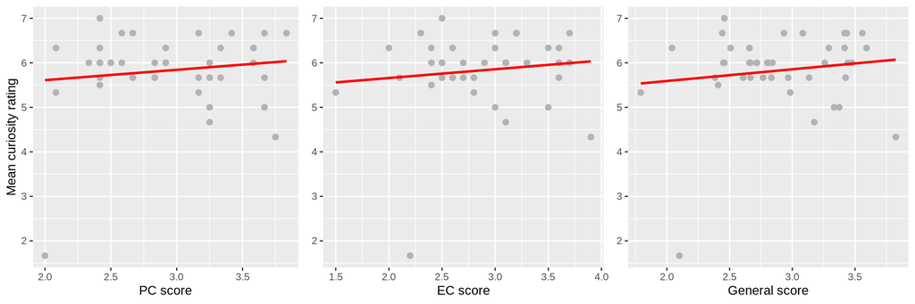

```
##
##  Pearson's product-moment correlation
##
## data:  trait.ratings.novel$meanCurRating and trait.ratings.novel$PC
## t = 0.84926, df = 38, p-value = 0.4011
## alternative hypothesis: true correlation is not equal to 0
## 95 percent confidence interval:
##  -0.1828022  0.4297189
## sample estimates:
##       cor
## 0.1364788
```

```
##
##  Pearson's product-moment correlation
##
## data:  trait.ratings.novel$meanCurRating and trait.ratings.novel$EC
## t = 0.73859, df = 38, p-value = 0.4647
## alternative hypothesis: true correlation is not equal to 0
## 95 percent confidence interval:
##  -0.1999553  0.4150908
## sample estimates:
##       cor
## 0.1189641
```

```
##
##  Pearson's product-moment correlation
##
## data:  trait.ratings.novel$meanCurRating and trait.ratings.novel$GN
## t = 0.88132, df = 38, p-value = 0.3837
## alternative hypothesis: true correlation is not equal to 0
## 95 percent confidence interval:
##  -0.1778184  0.4339097
## sample estimates:
##       cor
## 0.1415306
```

# 4 Relationship between trait score and memory performance

Here *memory performance* refers to the average corrected hit rate for “seen” response for items and average corrected hit rate for source memory.

## 4.1 Outside

### 4.1.1 Item recollection

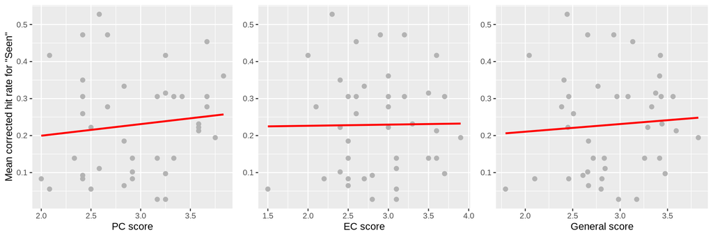

```
##
##  Pearson's product-moment correlation
##
## data:  outside.hit.rate.trait$meanSAcc and outside.hit.rate.trait$PC
## t = 0.73035, df = 38, p-value = 0.4697
## alternative hypothesis: true correlation is not equal to 0
## 95 percent confidence interval:
##  -0.2012295  0.4139913
## sample estimates:
##      cor
## 0.117655
```

```
##
##  Pearson's product-moment correlation
##
## data:  outside.hit.rate.trait$meanSAcc and outside.hit.rate.trait$EC
## t = 0.074837, df = 38, p-value = 0.9407
## alternative hypothesis: true correlation is not equal to 0
## 95 percent confidence interval:
##  -0.3005065  0.3224293
## sample estimates:
##        cor
## 0.01213925
```

```
##
##  Pearson's product-moment correlation
##
## data:  outside.hit.rate.trait$meanSAcc and outside.hit.rate.trait$GN
## t = 0.43983, df = 38, p-value = 0.6626
## alternative hypothesis: true correlation is not equal to 0
## 95 percent confidence interval:
##  -0.2457899  0.3743780
## sample estimates:
##        cor
## 0.07116852
```

### 4.1.2 Source memory

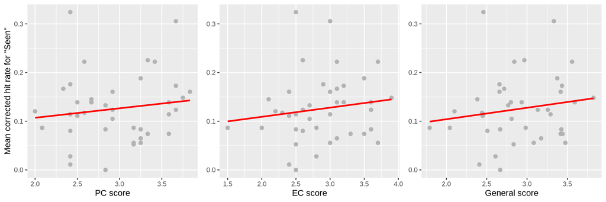

```
##
##  Pearson's product-moment correlation
##
## data:  outside.hit.rate.trait$meanSrcAcc and outside.hit.rate.trait$PC
## t = 0.90671, df = 38, p-value = 0.3703
## alternative hypothesis: true correlation is not equal to 0
## 95 percent confidence interval:
##  -0.1738693  0.4372118
## sample estimates:
##       cor
## 0.1455218
```

```
##
##  Pearson's product-moment correlation
##
## data:  outside.hit.rate.trait$meanSrcAcc and outside.hit.rate.trait$EC
## t = 0.90237, df = 38, p-value = 0.3725
## alternative hypothesis: true correlation is not equal to 0
## 95 percent confidence interval:
##  -0.1745440  0.4366487
## sample estimates:
##       cor
## 0.1448406
```

```
##
##  Pearson's product-moment correlation
##
## data:  outside.hit.rate.trait$meanSrcAcc and outside.hit.rate.trait$GN
## t = 1.0058, df = 38, p-value = 0.3209
## alternative hypothesis: true correlation is not equal to 0
## 95 percent confidence interval:
##  -0.158430  0.449965
## sample estimates:
##       cor
## 0.1610264
```

## 4.2 Inside

### 4.2.1 Item recollection

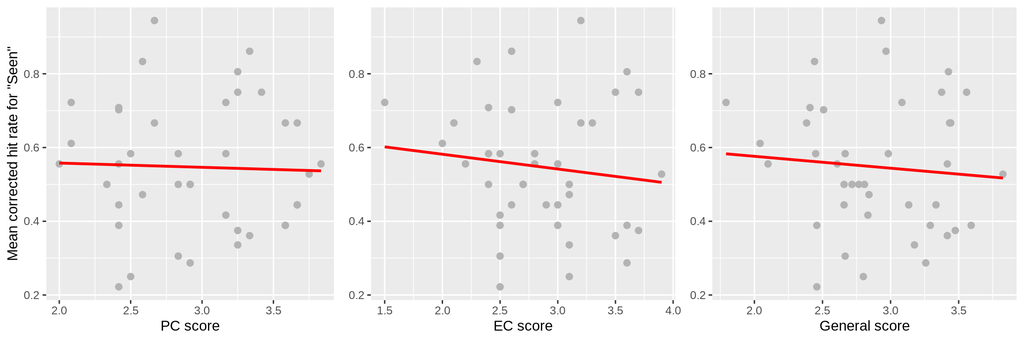

```
##
##  Pearson's product-moment correlation
##
## data:  inside.hit.rate.trait$meanSAcc and inside.hit.rate.trait$PC
## t = -0.20987, df = 38, p-value = 0.8349
## alternative hypothesis: true correlation is not equal to 0
## 95 percent confidence interval:
##  -0.3419113  0.2804560
## sample estimates:
##       cor
## -0.034026
```

```
##
##  Pearson's product-moment correlation
##
## data:  inside.hit.rate.trait$meanSAcc and inside.hit.rate.trait$EC
## t = -0.75317, df = 38, p-value = 0.456
## alternative hypothesis: true correlation is not equal to 0
## 95 percent confidence interval:
##  -0.4170325  0.1976999
## sample estimates:
##        cor
## -0.1212784
```

```
##
##  Pearson's product-moment correlation
##
## data:  inside.hit.rate.trait$meanSAcc and inside.hit.rate.trait$GN
## t = -0.53712, df = 38, p-value = 0.5943
## alternative hypothesis: true correlation is not equal to 0
## 95 percent confidence interval:
##  -0.3878256  0.2309512
## sample estimates:
##         cor
## -0.08680308
```

### 4.2.2 Source memory

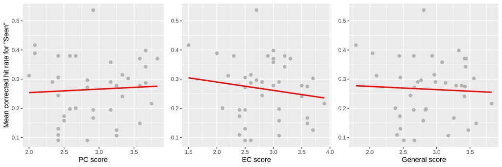

```
##
##  Pearson's product-moment correlation
##
## data:  inside.hit.rate.trait$meanSrcAcc and inside.hit.rate.trait$PC
## t = 0.36501, df = 38, p-value = 0.7171
## alternative hypothesis: true correlation is not equal to 0
## 95 percent confidence interval:
##  -0.2571344  0.3639180
## sample estimates:
##        cor
## 0.05910956
```

```
##
##  Pearson's product-moment correlation
##
## data:  inside.hit.rate.trait$meanSrcAcc and inside.hit.rate.trait$EC
## t = -0.90776, df = 38, p-value = 0.3697
## alternative hypothesis: true correlation is not equal to 0
## 95 percent confidence interval:
##  -0.4373484  0.1737055
## sample estimates:
##        cor
## -0.1456871
```

```
##
##  Pearson's product-moment correlation
##
## data:  inside.hit.rate.trait$meanSrcAcc and inside.hit.rate.trait$GN
## t = -0.3061, df = 38, p-value = 0.7612
## alternative hypothesis: true correlation is not equal to 0
## 95 percent confidence interval:
##  -0.3556101  0.2660246
## sample estimates:
##         cor
## -0.04959466
```

# 5 Relationship between trait score and memory performance within *Novel* rooms

Here *memory performance* refers to the average corrected hit rate for “seen” response for items and average corrected hit rate for source memory.

## 5.1 Outside

### 5.1.1 Item recollection

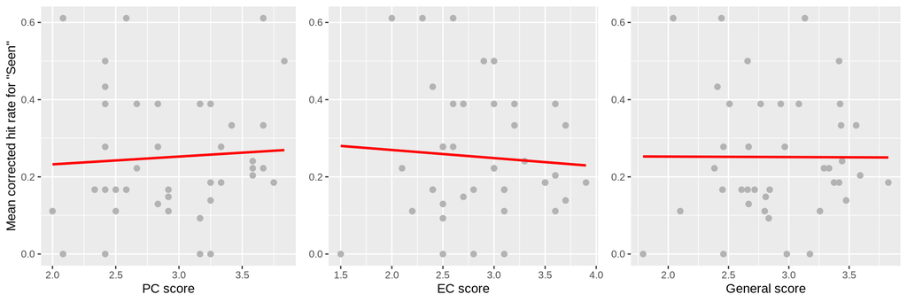

```
##
##  Pearson's product-moment correlation
##
## data:  outside.hit.rate.trait.novel$meanSAcc and outside.hit.rate.trait.novel$PC
## t = 0.38829, df = 38, p-value = 0.7
## alternative hypothesis: true correlation is not equal to 0
## 95 percent confidence interval:
##  -0.2536117  0.3671830
## sample estimates:
##        cor
## 0.06286409
```

```
##
##  Pearson's product-moment correlation
##
## data:  outside.hit.rate.trait.novel$meanSAcc and outside.hit.rate.trait.novel$EC
## t = -0.41653, df = 38, p-value = 0.6794
## alternative hypothesis: true correlation is not equal to 0
## 95 percent confidence interval:
##  -0.3711311  0.2493297
## sample estimates:
##         cor
## -0.06741576
```

```
##
##  Pearson's product-moment correlation
##
## data:  outside.hit.rate.trait.novel$meanSAcc and outside.hit.rate.trait.novel$GN
## t = -0.021756, df = 38, p-value = 0.9828
## alternative hypothesis: true correlation is not equal to 0
## 95 percent confidence interval:
##  -0.3146926  0.3083191
## sample estimates:
##          cor
## -0.003529236
```

### 5.1.2 Source memory

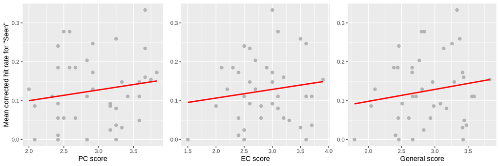

```
##
##  Pearson's product-moment correlation
##
## data:  outside.hit.rate.trait.novel$meanSrcAcc and outside.hit.rate.trait.novel$PC
## t = 1.0187, df = 38, p-value = 0.3148
## alternative hypothesis: true correlation is not equal to 0
## 95 percent confidence interval:
##  -0.1564148  0.4516114
## sample estimates:
##       cor
## 0.1630385
```

```
##
##  Pearson's product-moment correlation
##
## data:  outside.hit.rate.trait.novel$meanSrcAcc and outside.hit.rate.trait.novel$EC
## t = 0.84117, df = 38, p-value = 0.4055
## alternative hypothesis: true correlation is not equal to 0
## 95 percent confidence interval:
##  -0.1840581  0.4286588
## sample estimates:
##       cor
## 0.1352033
```

```
##
##  Pearson's product-moment correlation
##
## data:  outside.hit.rate.trait.novel$meanSrcAcc and outside.hit.rate.trait.novel$GN
## t = 1.0325, df = 38, p-value = 0.3084
## alternative hypothesis: true correlation is not equal to 0
## 95 percent confidence interval:
##  -0.1542604  0.4533671
## sample estimates:
##       cor
## 0.1651867
```

## 5.2 Inside

### 5.2.1 Item recollection

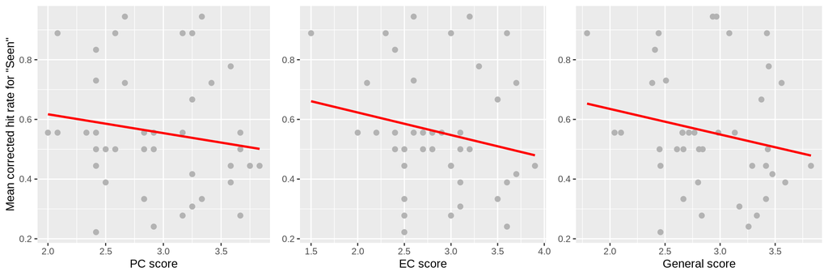

```
##
##  Pearson's product-moment correlation
##
## data:  inside.hit.rate.trait.novel$meanSAcc and inside.hit.rate.trait.novel$PC
## t = -1.0025, df = 38, p-value = 0.3225
## alternative hypothesis: true correlation is not equal to 0
## 95 percent confidence interval:
##  -0.4495444  0.1589439
## sample estimates:
##        cor
## -0.1605128
```

```
##
##  Pearson's product-moment correlation
##
## data:  inside.hit.rate.trait.novel$meanSAcc and inside.hit.rate.trait.novel$EC
## t = -1.2381, df = 38, p-value = 0.2233
## alternative hypothesis: true correlation is not equal to 0
## 95 percent confidence interval:
##  -0.4790438  0.1220778
## sample estimates:
##        cor
## -0.1969201
```

```
##
##  Pearson's product-moment correlation
##
## data:  inside.hit.rate.trait.novel$meanSAcc and inside.hit.rate.trait.novel$GN
## t = -1.2485, df = 38, p-value = 0.2195
## alternative hypothesis: true correlation is not equal to 0
## 95 percent confidence interval:
##  -0.4803168  0.1204485
## sample estimates:
##        cor
## -0.1985091
```

### 5.2.2 Source memory

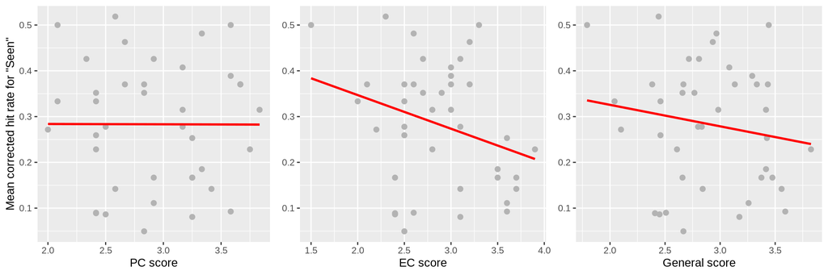

```
##
##  Pearson's product-moment correlation
##
## data:  inside.hit.rate.trait.novel$meanSrcAcc and inside.hit.rate.trait.novel$PC
## t = -0.017291, df = 38, p-value = 0.9863
## alternative hypothesis: true correlation is not equal to 0
## 95 percent confidence interval:
##  -0.3140399  0.3089744
## sample estimates:
##          cor
## -0.002804903
```

```
##
##  Pearson's product-moment correlation
##
## data:  inside.hit.rate.trait.novel$meanSrcAcc and inside.hit.rate.trait.novel$EC
## t = -1.8676, df = 38, p-value = 0.06955
## alternative hypothesis: true correlation is not equal to 0
## 95 percent confidence interval:
##  -0.55163089  0.02370523
## sample estimates:
##        cor
## -0.2899452
```

```
##
##  Pearson's product-moment correlation
##
## data:  inside.hit.rate.trait.novel$meanSrcAcc and inside.hit.rate.trait.novel$GN
## t = -1.0285, df = 38, p-value = 0.3102
## alternative hypothesis: true correlation is not equal to 0
## 95 percent confidence interval:
##  -0.4528639  0.1548785
## sample estimates:
##        cor
## -0.1645707
```

# 6 Relationship between trait score and curiosity ratings between *Familiar* and *Novel* rooms

Here *performance difference* refers to difference in item recollection and source memory between the *novel* and *familiar* rooms (*novel* - *familiar*).

## 6.1 See whether the curiosity ratings are significantly different between *novel* and *familiar* rooms

The average curiosity rating for the *novel* rooms is 5.83 (SD = $\pm$ 0.88).

The average curiosity rating for the *familiar* rooms is 3.03 (SD = $\pm$ 1.09).

```
##
##  One Sample t-test
##
## data:  outside.hit.rate.trait.diff$diffRating
## t = 12.268, df = 39, p-value = 5.803e-15
## alternative hypothesis: true mean is not equal to 0
## 95 percent confidence interval:
##  2.334853 3.256814
## sample estimates:
## mean of x
##  2.795833
```

## 6.2 See whether the difference in curiosity ratings are significantly correlated with trait scores

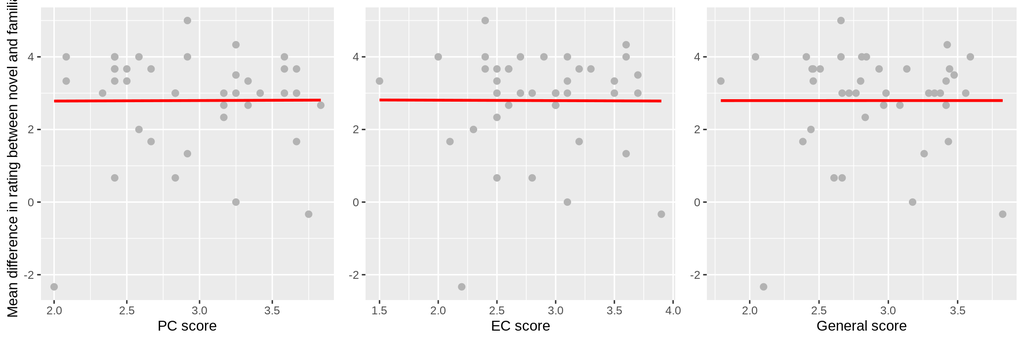

```
##
##  Pearson's product-moment correlation
##
## data:  outside.hit.rate.trait.diff$diffRating and outside.hit.rate.trait.diff$PC
## t = 0.031342, df = 38, p-value = 0.9752
## alternative hypothesis: true correlation is not equal to 0
## 95 percent confidence interval:
##  -0.3069112  0.3160929
## sample estimates:
##        cor
## 0.00508422
```

```
##
##  Pearson's product-moment correlation
##
## data:  outside.hit.rate.trait.diff$diffRating and outside.hit.rate.trait.diff$EC
## t = -0.027092, df = 38, p-value = 0.9785
## alternative hypothesis: true correlation is not equal to 0
## 95 percent confidence interval:
##  -0.3154723  0.3075356
## sample estimates:
##          cor
## -0.004394802
```

```
##
##  Pearson's product-moment correlation
##
## data:  outside.hit.rate.trait.diff$diffRating and outside.hit.rate.trait.diff$GN
## t = 0.0019062, df = 38, p-value = 0.9985
## alternative hypothesis: true correlation is not equal to 0
## 95 percent confidence interval:
##  -0.3112301  0.3117885
## sample estimates:
##          cor
## 0.0003092256
```

### 6.2.1 Looking at the trait-rating correlation separately for the *novel* and *familiar* rooms

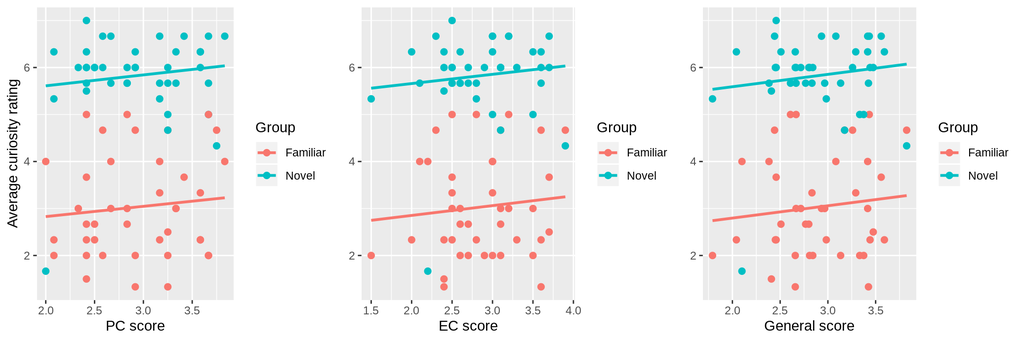

# 7 Relationship between trait score and performance differences between *Familiar* and *Novel* rooms

Here *performance difference* refers to difference in item recollection and source memory between the *novel* and *familiar* rooms (*novel* - *familiar*).

## 7.1 Outside

### 7.1.1 Item recollection

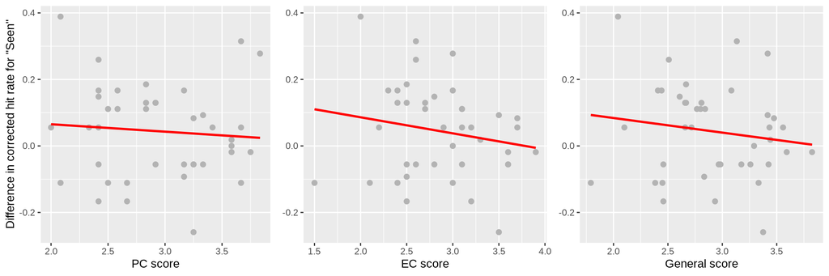

### 7.1.2 Source memory

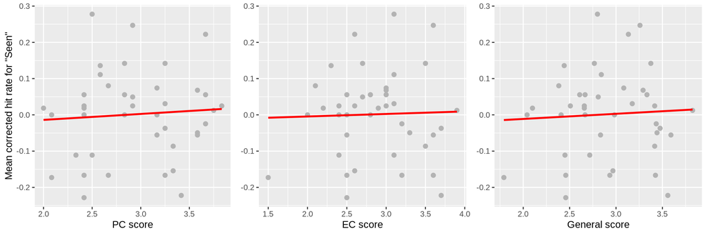

```
##
##  Pearson's product-moment correlation
##
## data:  outside.hit.rate.trait.diff$diffSrcAcc and outside.hit.rate.trait.diff$PC
## t = 0.43503, df = 38, p-value = 0.666
## alternative hypothesis: true correlation is not equal to 0
## 95 percent confidence interval:
##  -0.2465190  0.3737105
## sample estimates:
##        cor
## 0.07039631
```

```
##
##  Pearson's product-moment correlation
##
## data:  outside.hit.rate.trait.diff$diffSrcAcc and outside.hit.rate.trait.diff$EC
## t = 0.18888, df = 38, p-value = 0.8512
## alternative hypothesis: true correlation is not equal to 0
## 95 percent confidence interval:
##  -0.283589  0.338902
## sample estimates:
##        cor
## 0.03062583
```

```
##
##  Pearson's product-moment correlation
##
## data:  outside.hit.rate.trait.diff$diffSrcAcc and outside.hit.rate.trait.diff$GN
## t = 0.34401, df = 38, p-value = 0.7327
## alternative hypothesis: true correlation is not equal to 0
## 95 percent confidence interval:
##  -0.2603086  0.3609631
## sample estimates:
##        cor
## 0.05571894
```

## 7.2 Inside

### 7.2.1 Item recollection

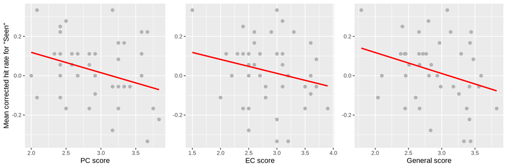

```
##
##  Pearson's product-moment correlation
##
## data:  inside.hit.rate.trait.diff$diffSAcc and inside.hit.rate.trait.diff$PC
## t = -2.0278, df = 38, p-value = 0.04964
## alternative hypothesis: true correlation is not equal to 0
## 95 percent confidence interval:
##  -0.568633593 -0.001068979
## sample estimates:
##        cor
## -0.3124743
```

```
##
##  Pearson's product-moment correlation
##
## data:  inside.hit.rate.trait.diff$diffSAcc and inside.hit.rate.trait.diff$EC
## t = -1.3908, df = 38, p-value = 0.1724
## alternative hypothesis: true correlation is not equal to 0
## 95 percent confidence interval:
##  -0.49748603  0.09815535
## sample estimates:
##        cor
## -0.2200833
```

```
##
##  Pearson's product-moment correlation
##
## data:  inside.hit.rate.trait.diff$diffSAcc and inside.hit.rate.trait.diff$GN
## t = -1.9006, df = 38, p-value = 0.06495
## alternative hypothesis: true correlation is not equal to 0
## 95 percent confidence interval:
##  -0.5551903  0.0185767
## sample estimates:
##        cor
## -0.2946377
```

### 7.2.2 Source memory

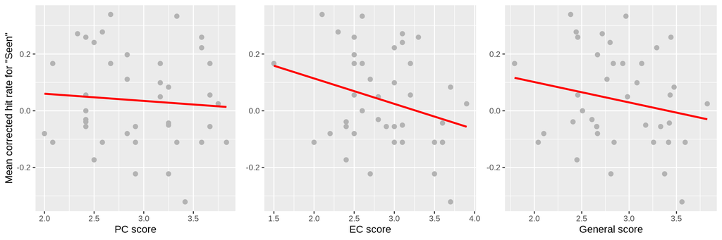

```
##
##  Pearson's product-moment correlation
##
## data:  inside.hit.rate.trait.diff$diffSrcAcc and inside.hit.rate.trait.diff$PC
## t = -0.48839, df = 38, p-value = 0.6281
## alternative hypothesis: true correlation is not equal to 0
## 95 percent confidence interval:
##  -0.3811130  0.2383943
## sample estimates:
##         cor
## -0.07898025
```

```
##
##  Pearson's product-moment correlation
##
## data:  inside.hit.rate.trait.diff$diffSrcAcc and inside.hit.rate.trait.diff$EC
## t = -1.8445, df = 38, p-value = 0.07292
## alternative hypothesis: true correlation is not equal to 0
## 95 percent confidence interval:
##  -0.54913043  0.02728994
## sample estimates:
##        cor
## -0.2866563
```

```
##
##  Pearson's product-moment correlation
##
## data:  inside.hit.rate.trait.diff$diffSrcAcc and inside.hit.rate.trait.diff$GN
## t = -1.287, df = 38, p-value = 0.2059
## alternative hypothesis: true correlation is not equal to 0
## 95 percent confidence interval:
##  -0.4850103  0.1144139
## sample estimates:
##        cor
## -0.2043798
```